# Most common and efficient shots per team

Derek Corcoran

February 8, 2017

## Most common shots in the game

The nba stats webpage classifies shots as one of the following types *Driving Layup Shot, Hook Shot, Jump Shot, Tip Layup Shot, Cutting Layup Shot, Floating Jump shot, Turnaround Jump Shot, Layup Shot, Running Layup Shot, Alley Oop Dunk Shot, Putback Dunk Shot, Step Back Jump shot, Running Dunk Shot, Running Reverse Layup Shot, Dunk Shot, Pullup Jump shot, Driving Dunk Shot, Fadeaway Jump Shot, Jump Bank Shot, Driving Bank shot, Finger Roll Layup Shot, Turnaround Hook Shot, Reverse Layup Shot, Putback Layup Shot, Driving Floating Jump Shot, Driving Finger Roll Layup Shot, Cutting Dunk Shot, Driving Reverse Layup Shot, Reverse Dunk Shot, Driving Hook Shot, Driving Floating Bank Jump Shot, Turnaround Fadeaway shot, Running Jump Shot, Running Finger Roll Layup Shot, Alley Oop Layup shot, Driving Bank Hook Shot, Turnaround Fadeaway Bank Jump Shot, Turnaround Bank shot, Fadeaway Bank shot, Turnaround Bank Hook Shot, Tip Dunk Shot, Running Pull-Up Jump Shot, Pullup Bank shot, Cutting Finger Roll Layup Shot, Running Reverse Dunk Shot, Driving Reverse Dunk Shot, Step Back Bank Jump Shot, Hook Bank Shot, Running Alley Oop Dunk Shot, Running Alley Oop Layup Shot, Driving Jump shot, Running Hook Shot*

## Cleaning of the data

This clearly has to be filtered further joined, for example the Layup Shot 2 should be the same category as Driving Layup Shot I think. we can discuss this further.

For now, I found the 6 most tipicall shots made in the NBA, measure by proportion of shots taken overall (Prop). And also calculated the points per shot for each kind of shot(PPS).

| ACTION_TYPE | Prop | PPS |
| --- | --- | --- |
| Jump Shot 3 | 0.28 | 1.03 |
| Jump Shot 2 | 0.18 | 0.59 |
| Layup Shot 2 | 0.08 | 0.81 |
| Driving Layup Shot 2 | 0.06 | 1.18 |
| Pullup Jump shot 2 | 0.05 | 1.06 |
| Floating Jump shot 2 | 0.02 | 0.93 |

## Sortable table by team

Then I made that information for each team, as you can see, the team that is more monotematic is the Houston Rockets (no surprise there) where more than 40% of their shots are three pointers, you can use the arrows to sort by any of the given categories.Let me know if you think of something with this.

|  | ACTION_TYPE | Prop | PPS | TEAM |
| --- | --- | --- | --- | --- |
| 1 | Jump Shot 3 | 0.403 | 1.042 | Hou |
| 2 | Jump Shot 3 | 0.374 | 1.136 | Cle |
| 3 | Jump Shot 3 | 0.361 | 0.991 | Bkn |
| 4 | Jump Shot 3 | 0.355 | 1.08 | Bos |
| 5 | Jump Shot 3 | 0.334 | 1.039 | Dal |
| 6 | Jump Shot 3 | 0.322 | 1.022 | Phi |
| 7 | Jump Shot 3 | 0.31 | 1.04 | Uta |
| 8 | Jump Shot 3 | 0.296 | 0.986 | Cha |
| 9 | Jump Shot 3 | 0.294 | 1.063 | Sac |
| 10 | Jump Shot 3 | 0.292 | 1.064 | Mia |

[output cut: 176 more lines]

## Are teams choosing their most efficient shots?

One question worth asking is if teams shoot more the shots that they are more efficient at (more pps).

```
##
## Call:
## lm(formula = PPS ~ Prop, data = DF2)
##
## Residuals:
##      Min       1Q   Median       3Q      Max
## -0.53381 -0.17220  0.01906  0.16310  0.52856
##
## Coefficients:
##             Estimate Std. Error t value Pr(>|t|)
## (Intercept)  0.98209    0.02523  38.929   <2e-16 ***
## Prop        -0.40103    0.16977  -2.362   0.0192 *
## ---
## Signif. codes:  0 '***' 0.001 '**' 0.01 '*' 0.05 '.' 0.1 ' ' 1
##
## Residual standard error: 0.22 on 184 degrees of freedom
## Multiple R-squared:  0.02943,    Adjusted R-squared:  0.02416
## F-statistic:  5.58 on 1 and 184 DF,  p-value: 0.01921
```

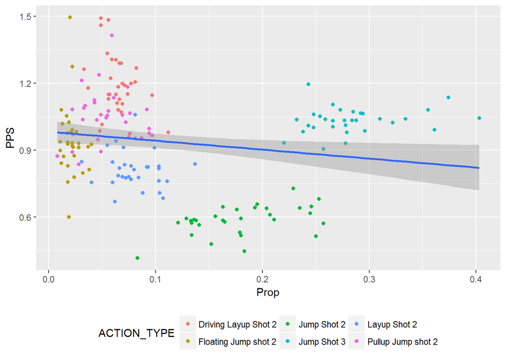